# 3. Graphs

3. Graphs

WU Xiaokun 吴晓堃

xkun.wu [at] gmail

2021/10/15

## Graphs in Discrete Math

Computer deals with discrete mathematics.

- core subject: combinatorial structures
- graphs: fundamental, expressive

# Basic Definitions

## Undirected graphs

**Notation**. $G = (V, E)$

- $V$: nodes (or vertices).
- $E$: edges (or arcs) between pairs of nodes.
- Captures pairwise relationship between objects.
- Graph size parameters: $n = | V |, m = | E |$.

$V = \{ 1, 2, 3, 4, 5, 6, 7, 8 \}$  
$E = \{ 1–2, 1–3, 2–3, 2–4, 2–5, 3–5, 3–7, 3–8, 4–5, 5–6, 7–8 \}$  
$m = 11, n = 8$

## Examples of Graphs

| graph | node | edge |
| --- | --- | --- |
| communication | telephone, computer | fiber optic cable |
| circuit | gate, register, processor | wire |
| mechanical | joint | rod, beam, spring |
| financial | stock, currency | transactions |
| transportation | street intersection, airport | highway, airway route |
| internet | network hub | connection |
| game | board position | legal move |
| social relationship | person, actor | friendship, movie cast |
| neural network | neuron | synapse |
| protein network | protein | protein-protein interaction |
| molecule | atom | bond |

## Graph representation: adjacency matrix

**Adjacency matrix**. $n$-by-$n$ matrix with $A_{uv} = 1$ if $(u, v)$ is an edge.

- Two representations of each edge.
- Space proportional to $n^2$.
- Check if $(u, v)$ is an edge: $\Theta(1)$ time.
- Identify all edges: $\Theta(n^2)$ time.

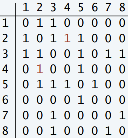

## Graph representation: adjacency lists

**Adjacency lists**. Node-indexed array of lists.

- Two representations of each edge.
- Space is $\Theta(m + n)$.
- Check if $(u, v)$ is an edge: $O(degree(u))$ time.
- Identify all edges: $\Theta(m + n)$ time.

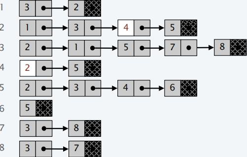

## Graph representation: space requirement

**Degree $n_v$** of a node $v$: the number of *incident* edges it has.

**Sum of the degrees**. $\sum_{v \in V} n_v = 2m$.  
**Pf**. Each edge $e = (v, w)$ contributes exactly twice to this sum.

**Theorem**. Adjacency matrix representation of a graph requires $O(n^2)$ space; Adjacency list representation requires only $O(m + n)$ space.

- since $m \le n^2$, the bound $O(m + n)$ is never worse than $O(n^2)$
  - adjacency list is a natural representation for exploring graphs.

## Paths and connectivity

**Def**. A **path** in an undirected graph $G = (V, E)$ is a sequence of nodes $v_1, v_2, \ldots, v_k$ with the property that each consecutive pair $v_{i–1}, v_i$ is joined by a different edge in $E$.

**Def**. A path is **simple** if all nodes are distinct.

**Def**. An undirected graph is **connected** if for every pair of nodes $u$ and $v$, there is a path between them.

## Cycles

**Def**. A **cycle** is a path $v_1, v_2, \ldots, v_k$ in which $v_1 = v_k$ and $k \ge 2$.

**Def**. A cycle is **simple** if all nodes are distinct (except for $v_1$ and $v_k$).

## Trees

**Def**. An undirected graph is a **tree** if it is connected and contains no cycle.

**Theorem**. Let $G$ be an undirected graph on $n$ odes. Any two of the following statements imply the third:

- $G$ is connected.
- $G$ does not contain a cycle.
- $G$ has $n – 1$ edges.

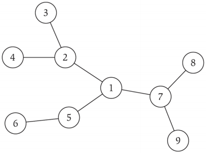

## Rooted trees

**Rooted tree**. Given a tree $T$, choose a root node $r$ and orient each edge away from $r$.

**Importance**. Models hierarchical structure.

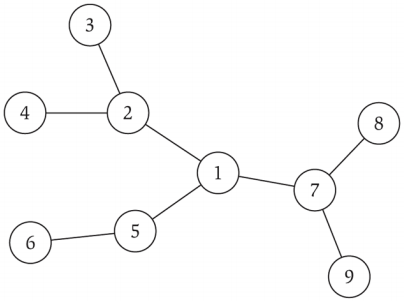

[figure not shown]

# Graph Connectivity and Graph Traversal

## Connectivity

**s-t connectivity problem**. Given two nodes $s$ and $t$, is there a path between them?

**s-t shortest path problem**. Given two nodes $s$ and $t$, what is the length of a shortest path between them?

**Applications**.

- Maze traversal.
- Fewest hops in a communication network.

## Breadth-first search (BFS)

**BFS intuition**. Start at root $s$ and “flood” the graph.

- Explore outward from $s$ in all possible directions,
- Adding nodes one “layer” at a time.

**BFS algorithm**.

- $L_0$: $\{ s \}$.
- $L_1$: all neighbors of $L_0$.
- $L_{i+1}$: all nodes that do not belong to an earlier layer, and that have an edge to a node in $L_i$.

**Theorem**. For each $i \ge 1$, $L_i$ consists of all nodes at distance exactly $i$ from $s$. There is a path from $s$ to $t$ iff $t$ appears in some layer.

- produce a tree with root $s$

## BFS tree

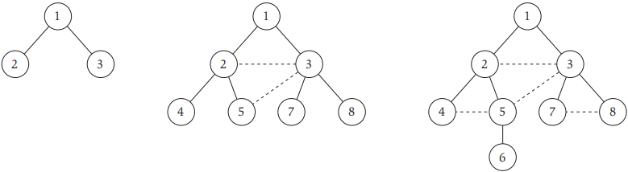

**Note**: non-tree edges all either connected nodes in the same layer, or connected nodes in adjacent layers.

## BFS tree property

**Property**. Let $T$ be a breadth-first search tree, let $x$ and $y$ be nodes in $T$ belonging to layers $L_i$ and $L_j$ respectively, and let $(x, y)$ be an edge of $G$. Then $i$ and $j$ differ by at most 1.  
**Pf**.

- consider the moment BFS just examined $x$
  - nodes discovered from $x$ belong to layers $L_{i+1}$ or earlier

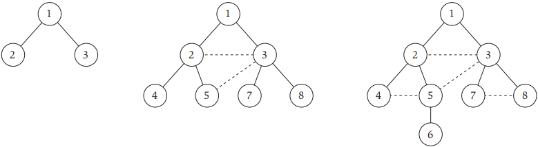

## BFS: representation

BFS corresponds exactly to *queue* structure.

- extract elements in *first-in, first-out (FIFO)* order
- can be implemented via *doubly linked list*

Array `Discovered` of length $n$

- set `Discovered[v]= true` as soon as our search first sees $v$.

## BFS: implementation

`Discovered`[$s$] = `true`; `Discovered`[$v$] = `false` for all other $v$;  
$L[0] = \{s\}$; layer counter $i = 0$; current tree $T = \{\}$;  
While $L[i]$ is not empty:

- Initialize an empty list $L[i + 1]$;
- For each node $u \in L[i]$:
  - Consider each edge $(u, v)$ incident to $u$:
  - If `Discovered`[v] = `false`:
    - Set `Discovered`[v] = `true`;
    - Add edge $(u, v)$ to the tree $T$;
    - Add $v$ to the list $L[i + 1]$;
  - ++$i$;

## BFS: analysis

**Theorem**. The above implementation of the BFS algorithm runs in time O(m + n) (i.e., linear in the input size), if the graph is given by the adjacency list representation.  
**Pf**.

- easy to prove $O(n^2)$ time
  - at most $n$ lists $L[i]$
    - for loop runs at most $n$ times
  - at most $n$ neighbors for each node
    - each spend $O(1)$ time
- Actually runs in $O(m + n)$ time:
  - each node $u$ has $degree(u)$ neighbors
    - total time processing edges: $O(\sum_{v \in V} n_v = 2m) = O(m)$
  - $O(n)$ additional time: set up lists, manage `Discovered`.

## Depth-First Search (DFS)

**DFS intuition**: explore a maze.

- keep going until reached a “dead end”
  - backtrack until an unexplored branch

**Depth-first search tree**: non-tree edges can only connect ancestors to descendants.

## Depth-first search tree

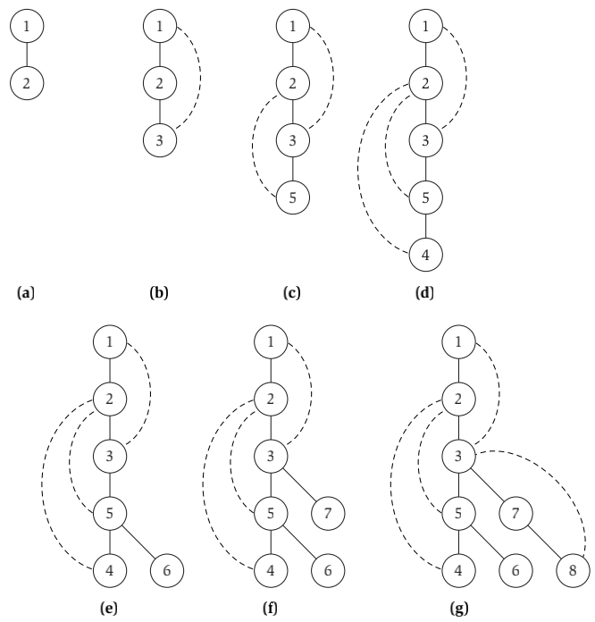

## DFS: representation

DFS corresponds exactly to *stack* structure.

- extract elements in *last-in, first-out (LIFO)* order
- can be implemented via *doubly linked list*

Array `Discovered` of length $n$

- set `Discovered[v]= true` as soon as our search first sees $v$.

## Application: connected component

**Connected component**. Find all nodes reachable from $s$.

- Initially R = {s}
- While there is an edge $(u, v)$ where $u \in R$ and $v \notin R$
  - Add $v$ to $R$

**Theorem**. Upon termination, $R$ is the connected component containing $s$.

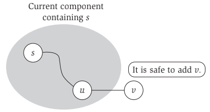

- **BFS**: explore in order of distance from s.
- **DFS**: explore in a recursive way.

# Testing Bipartiteness

## Bipartite graphs

**Def**. An undirected graph $G = (V, E)$ is **bipartite** if the nodes can be colored blue or `white` such that every edge has one `white` and one `blue` end.

**Applications**.

- Stable matching: men = `blue`, women = `white`.
- Scheduling: machines = `blue`, jobs = `white`.

## Testing bipartiteness

Many graph problems become:

- *Easier* if the underlying graph is bipartite (matching).
- *Tractable* if the underlying graph is bipartite (independent set).

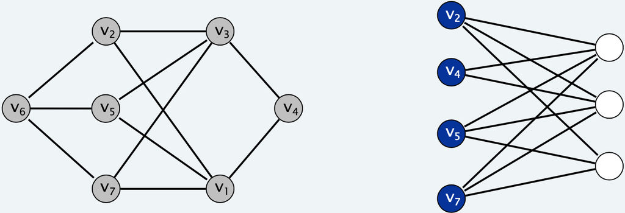

Before attempting to design an algorithm, we need to understand structure of bipartite graphs.

## An obstruction to bipartiteness

Clearly a triangle is not bipartite.

**Lemma**. If a graph $G$ is bipartite, it *cannot* contain an odd-length cycle.  
**Pf**. Not possible to 2-color the odd-length cycle, let alone $G$.

## Bipartiteness: BFS algorithm

**Lemma**. Let $G$ be a connected graph, and let $L_0, \ldots, L_k$ be the layers produced by BFS starting at node $s$. Exactly one of the following holds:

1. No edge of $G$ joins two nodes of the same layer, and $G$ is bipartite.
2. An edge of $G$ joins two nodes of the same layer, and $G$ contains an odd-length cycle (and hence is not bipartite).

## Bipartiteness: BFS algorithm, pf. I

**Lemma**. Let $G$ be a connected graph, and let $L_0, \ldots, L_k$ be the layers produced by BFS starting at node $s$. Exactly one of the following holds:

1. No edge of $G$ joins two nodes of the same layer, and $G$ is bipartite.
2. An edge of $G$ joins two nodes of the same layer, and $G$ contains an odd-length cycle (and hence is not bipartite).

**Pf**. (i)

- Suppose no edge joins two nodes in same layer.
- By BFS property, each edge joins two nodes in adjacent levels.
- Bipartition: `white` = nodes on odd levels, `blue` = nodes on even levels.

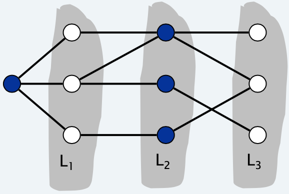

## Bipartiteness: BFS algorithm, pf. II

**Lemma**. Let $G$ be a connected graph, and let $L_0, \ldots, L_k$ be the layers produced by BFS starting at node $s$. Exactly one of the following holds:

1. No edge of $G$ joins two nodes of the same layer, and $G$ is bipartite.
2. An edge of $G$ joins two nodes of the same layer, and $G$ contains an odd-length cycle (and hence is not bipartite).

**Pf**. (ii)

- Suppose $(x, y)$ is an edge with $x, y$ in same level $L_j$.
  - Let $z = lca(x, y)$: *lowest common ancestor*.
  - Let $L_i$ be level containing $z$.
- Consider cycle that takes edge from $x$ to $y$, then path from $y$ to $z$, then path from $z$ to $x$.
- Its length is $1 + (j – i) + (j – i)$, which is odd.

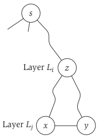

## The only obstruction to bipartiteness

**Corollary**. A graph $G$ is *bipartite* iff it contains no odd-length cycle.

# Connectivity in Directed Graphs

## Directed graphs

**Notation**. $G = (V, E)$.

- Edge $(u, v)$ leaves node $u$ and enters node $v$.

**Ex**. Web graph: hyperlink points from one web page to another.

- Orientation of edges is crucial.
- Modern web search engines exploit hyperlink structure to rank webpages by importance.

**Ex**. Road network

- Node = intersection;
- edge = one-way street.

## Graph search

**Directed reachability**. Given a node $s$, find all nodes reachable from $s$.

**Directed $s \leadsto t$ shortest path problem**. Given two nodes $s$ and $t$, what is the length of a shortest path between them?

**Graph search**. BFS extends naturally to directed graphs.

**Web crawler**. Start from web page $s$: find all web pages linked from $s$, either directly or indirectly.

## Strong connectivity

**Def**. Nodes $u$ and $v$ are **mutually reachable** if there is both a path from $u$ to $v$ and also a path from $v$ to $u$.

**Def**. A graph is **strongly connected** if every pair of nodes is mutually reachable.

**Lemma**. Let $s$ be any node. $G$ is *strongly connected* iff every node is reachable from $s$, and $s$ is reachable from every node.  
**Pf**. $\Rightarrow$ Follows from definition.  
**Pf**. $\Leftarrow$

- Path from $u$ to $v$: concatenate $u \leadsto s$ path with $s \leadsto v$ path.
- Path from $v$ to $u$: concatenate $v \leadsto s$ path with $s \leadsto u$ path.

## Strong connectivity: algorithm

**Theorem**. Can determine if $G$ is strongly connected in $O(m + n)$ time.  
**Pf**.

- Pick any node $s$.
- Run BFS from $s$ in $G$.
- Run BFS from $s$ in $G^{reverse}$.
- Return true iff all nodes reached in both BFS executions.
- Correctness follows immediately from previous lemma.

## Strong components

**Def**. A strong component is a maximal subset of mutually reachable nodes.

**Theorem**. [Tarjan 1972] Can find all strong components in $O(m + n)$ time.

# DAGs and Topological Ordering

## Directed acyclic graphs

**Def**. A **DAG** is a directed graph that contains no directed cycles.

**Def**. A **topological order** of a directed graph $G = (V, E)$ is an ordering of its nodes as $v_1, v_2, \ldots, v_n$ so that for every edge $(v_i, v_j)$ we have $i < j$.

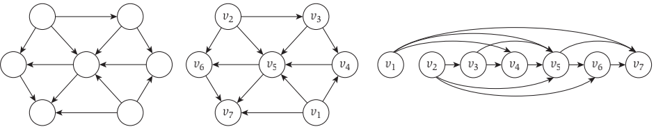

## Precedence constraints

**Precedence constraints**. Edge $(v_i, v_j)$ means task $v_i$ must occur before $v_j$.

**Applications**.

- Course prerequisite graph: course $v_i$ must be taken before $v_j$.
- Compilation: module $v_i$ must be compiled before $v_j$.
- Pipeline of computing jobs: output of job $v_i$ needed to determine input of job $v_j$.

## DAG: determinant

**Lemma**. If $G$ has a topological order, then $G$ is a DAG.  
**Pf**. [by contradiction]

- Suppose that $G$ has a topological order $v_1, v_2, \ldots, v_n$ and that $G$ also has a directed cycle $C$. Let’s see what happens.
- Let $v_i$ be the lowest-indexed node in $C$, and let $v_j$ be the node just before $v_i$; thus $(v_j, v_i)$ is an edge.
- By our choice of $i$, we have $i < j$.
- On the other hand, since $(v_j , v_i)$ is an edge and $v_1, v_2, \ldots, v_n$ is a topological order, we must have $j < i$, a contradiction.

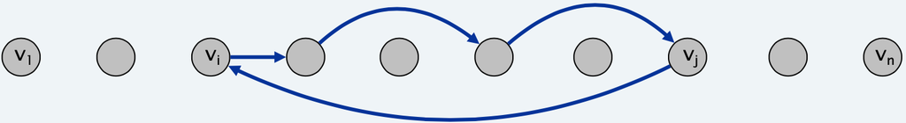

## DAG: head

**Lemma**. If $G$ is a DAG, then $G$ has a node with no entering edges.  
**Pf**. [by contradiction]

- Suppose that $G$ is a DAG and every node has at least one entering edge. Let’s see what happens.
- Pick any node $v$, and begin following edges backward from $v$. Since $v$ has at least one entering edge $(u, v)$ we can walk backward to $u$.
- Since $u$ has at least one entering edge $(x, u)$, we can walk backward to $x$.
- Repeat until we visit a node, say $w$, twice.
- Let $C$ denote the sequence of nodes encountered between successive visits to $w$. $C$ is a cycle.

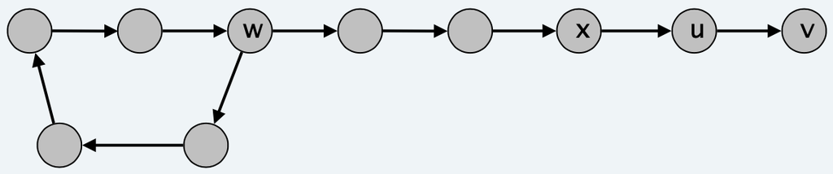

## DAG: property

**Lemma**. If $G$ is a DAG, then $G$ has a topological ordering.  
**Pf**. [by induction on n]

- Base case: true if n = 1.
- Given DAG on $n > 1$ nodes, find a node $v$ with no entering edges.
- $G – { v }$ is a DAG, since deleting $v$ cannot create cycles.
- By inductive hypothesis, $G – { v }$ has a topological ordering.
- Place $v$ first in topological ordering;
  - then append nodes of $G – { v }$ in topological order.
  - This is valid since v has no entering edges.

## TS algorithm: analysis

**Theorem**. Algorithm finds a topological order in $O(m + n)$ time.  
**Pf**.

- Maintain the following information:
  - $count(w)$ = remaining number of incoming edges
  - $S$: set of remaining nodes with no incoming edges
- Initialization: $O(m + n)$ via single scan through graph.
- Update: to delete $v$
  - remove $v$ from $S$
  - decrement $count(w)$ for all edges from $v$ to $w$
    - add $w$ to $S$ if $count(w)$ hits $0$
  - this is $O(1)$ per edge

## TS algorithm: example

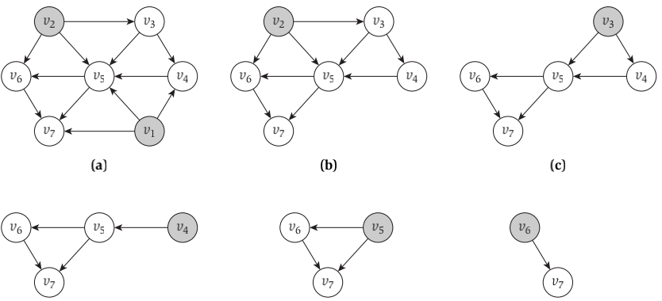